# EXT CSCI E-106 Model Data Class Group Project Template

Charles Atchison

2023-11-30

## Section 1: Data Preparation and Initial Analysis

### Load and Review the Dataset

**Task 1**: Load and review the dataset named “KC_House_Sale.csv”.

### Data Description Table

| Variable | Description |
| --- | --- |
| id | Unique ID for each home sold (it is not a predictor) |
| date | Date of the home sale |
| price | Price of each home sold |
| bedrooms | Number of bedrooms |
| bathrooms | Number of bathrooms, where “.5” accounts for a bathroom with a toilet but no shower |
| sqft_living | Square footage of the apartment interior living space |
| sqft_lot | Square footage of the land space |
| floors | Number of floors |
| waterfront | A dummy variable for whether the apartment was overlooking the waterfront or not |
| view | An index from 0 to 4 of how good the view of the property was |
| condition | An index from 1 to 5 on the condition of the apartment |
| grade | An index from 1 to 13, where 1-3 falls short of building construction and design, etc. |
| sqft_above | The square footage of the interior housing space that is above ground level |
| sqft_basement | The square footage of the interior housing space that is below ground level |
| yr_built | The year the house was initially built |
| yr_renovated | The year of the house’s last renovation |
| zipcode | What zipcode area the house is in |
| lat | Latitude |
| long | Longitude |
| sqft_living15 | The square footage of interior housing living space for the nearest 15 neighbors |
| sqft_lot15 | The square footage of the land lots of the nearest 15 neighbors |

### Data Splitting and Preprocessing

**Task 2**: Create the training dataset containing 70% of the data and use `set.seed(1023)`. Use the remaining 30% as the test dataset.

```r
# Set seed for reproducibility
set.seed(1023)

# Split the data into training and test sets
train_indices <- sample(1:nrow(kc_house_sales), 0.7 * nrow(kc_house_sales))
train_data <- kc_house_sales[train_indices, ]
test_data <- kc_house_sales[-train_indices, ]
```

**Task 3**: Investigate the data, modify levels of categorical variables if necessary, and drop non-essential variables such as `id`, `Latitude`, `Longitude`, etc.

```r
# Investigate the data
summary(train_data)
```

```
##        id                date              price              bedrooms
##  Min.   :1.000e+06   Length:15129       Length:15129       Min.   : 0.000
##  1st Qu.:2.125e+09   Class :character   Class :character   1st Qu.: 3.000
##  Median :3.905e+09   Mode  :character   Mode  :character   Median : 3.000
##  Mean   :4.583e+09                                         Mean   : 3.373
##  3rd Qu.:7.303e+09                                         3rd Qu.: 4.000
##  Max.   :9.900e+09                                         Max.   :33.000
##    bathrooms      sqft_living       sqft_lot           floors
##  Min.   :0.000   Min.   :  370   Min.   :    520   Min.   :1.000
##  1st Qu.:1.750   1st Qu.: 1430   1st Qu.:   5027   1st Qu.:1.000
##  Median :2.250   Median : 1910   Median :   7600   Median :1.500
##  Mean   :2.117   Mean   : 2080   Mean   :  14914   Mean   :1.498
##  3rd Qu.:2.500   3rd Qu.: 2550   3rd Qu.:  10735   3rd Qu.:2.000
##  Max.   :8.000   Max.   :12050   Max.   :1164794   Max.   :3.500
##    waterfront            view          condition         grade
##  Min.   :0.000000   Min.   :0.0000   Min.   :1.000   Min.   : 3.000
##  1st Qu.:0.000000   1st Qu.:0.0000   1st Qu.:3.000   1st Qu.: 7.000
##  Median :0.000000   Median :0.0000   Median :3.000   Median : 7.000
##  Mean   :0.006808   Mean   :0.2298   Mean   :3.413   Mean   : 7.657
##  3rd Qu.:0.000000   3rd Qu.:0.0000   3rd Qu.:4.000   3rd Qu.: 8.000
##  Max.   :1.000000   Max.   :4.0000   Max.   :5.000   Max.   :13.000
##    sqft_above   sqft_basement       yr_built     yr_renovated
##  Min.   : 370   Min.   :   0.0   Min.   :1900   Min.   :   0.00
##  1st Qu.:1190   1st Qu.:   0.0   1st Qu.:1951   1st Qu.:   0.00
##  Median :1560   Median :   0.0   Median :1975   Median :   0.00
##  Mean   :1787   Mean   : 292.6   Mean   :1971   Mean   :  85.06
##  3rd Qu.:2217   3rd Qu.: 560.0   3rd Qu.:1997   3rd Qu.:   0.00
##  Max.   :8570   Max.   :4820.0   Max.   :2015   Max.   :2015.00
##     zipcode           lat             long        sqft_living15
##  Min.   :98001   Min.   :47.16   Min.   :-122.5   Min.   : 399
##  1st Qu.:98033   1st Qu.:47.47   1st Qu.:-122.3   1st Qu.:1490
##  Median :98065   Median :47.57   Median :-122.2   Median :1840
##  Mean   :98078   Mean   :47.56   Mean   :-122.2   Mean   :1988
##  3rd Qu.:98117   3rd Qu.:47.68   3rd Qu.:-122.1   3rd Qu.:2370
##  Max.   :98199   Max.   :47.78   Max.   :-121.3   Max.   :6110
##    sqft_lot15
##  Min.   :   651
##  1st Qu.:  5100
##  Median :  7620
##  Mean   : 12728
##  3rd Qu.: 10100
##  Max.   :858132
```

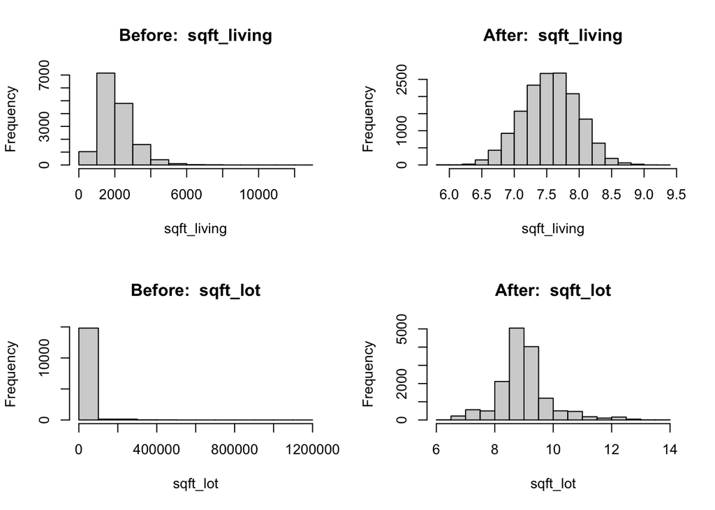

[figure not shown]

```r
# Function to clean and transform the data
# Parameters:
#   df: Input dataframe
#   evaluate_plots: Boolean flag to control histogram plotting
#   apply_transformations: Boolean flag to control log transformations
# Returns:
#   Cleaned and transformed dataframe
clean_transform_data <- function(df, evaluate_plots = FALSE, apply_transformations = TRUE) {
  # Ensure that 'df' is a dataframe
  if (!is.data.frame(df)) {
    stop("Input must be a dataframe")
  }

  # Convert columns to numeric as needed
  cols_to_numeric <- c("yr_built", "yr_renovated", "sqft_living", "sqft_lot", "sqft_living15", "sqft_lot15")
  df[cols_to_numeric] <- lapply(df[cols_to_numeric], function(x) as.numeric(as.character(x)))

  # Drop non-essential columns
  df <- df[, !(names(df) %in% c("id", "lat", "long"))]

  # Convert 'price' to numeric, handling any non-numeric characters
  df$price <- as.numeric(gsub("[^0-9.]", "", df$price))

  # Remove rows with NA or infinite 'price' values
  df <- df[!is.na(df$price) & !is.nan(df$price) & !is.infinite(df$price), ]

  # Handling the 'date' column
  df$date <- as.Date(substr(df$date, 1, 8), format="%Y%m%d")

  if (apply_transformations) {
    # Log transformation for skewed continuous variables
    skewed_vars <- c("sqft_living", "sqft_lot", "sqft_above")
    if (evaluate_plots) {
      par(mfrow = c(2, 2))  # Setting up the plotting area
    }
    for (var in skewed_vars) {
      if (evaluate_plots) {
        # Before transformation: Histogram plot
        hist(df[[var]], main = paste("Before: ", var), xlab = var)
      }
      df[[var]] <- log1p(df[[var]])
      if (evaluate_plots) {
        # After transformation: Histogram plot
        hist(df[[var]], main = paste("After: ", var), xlab = var)
      }
    }

    # Handling 'sqft_basement' separately due to potential NA values
    df$sqft_basement <- ifelse(is.na(df$sqft_basement), 0, df$sqft_basement)  # Replace NA with 0
    df$sqft_basement <- log1p(df$sqft_basement)

    if (evaluate_plots) {
      # Before transformation: Histogram plot for sqft_basement
      hist(df$sqft_basement, main = "Before: sqft_basement", xlab = "sqft_basement")
    }

    if (evaluate_plots) {
      par(mfrow = c(1, 1))  # Resetting the plotting area
    }
  }

  # Convert 'view', 'condition', and 'grade' to factors
  df$view <- factor(df$view)
  df$condition <- factor(df$condition)
  df$grade <- factor(df$grade)

  # Feature Engineering: Extracting date components
  df$year_sold <- year(df$date)
  df$month_sold <- month(df$date)
  df$day_sold <- day(df$date)

  # Additional date-time features
  df$season <- factor(quarter(df$date), labels = c("Winter", "Spring", "Summer", "Fall"))
  df$week_of_year <- week(df$date)
  df$day_of_year <- yday(df$date)

  # Remove the original 'date' column
  df <- df[, !names(df) %in% "date"]

  # Remove rows with any NA values
  df <- na.omit(df)

  return(df)
}

# Apply the function to both train and test datasets
train_data_cleaned <- clean_transform_data(train_data, evaluate_plots = TRUE, apply_transformations = TRUE)
```

```r
test_data_cleaned <- clean_transform_data(test_data, evaluate_plots = FALSE, apply_transformations = FALSE)
```

#### Converting Columns to Numeric

The first step involves converting specific columns (‘yr_built’, ‘yr_renovated’, ‘sqft_living’, ‘sqft_lot’, ‘sqft_living15’, ‘sqft_lot15’) to numeric data types. This conversion ensures that these columns are treated as numerical variables rather than character strings.

#### Dropping Non-Essential Columns

Non-essential columns such as ‘id’, ‘lat’, and ‘long’ are removed from the dataframe. These columns do not contain valuable information for our analysis and can be safely excluded to simplify the dataset.

#### Converting ‘price’ to Numeric

To work with the ‘price’ column effectively, we convert it to a numeric data type. This conversion involves removing any non-numeric characters that might be present in the ‘price’ values, ensuring that it can be used as a numerical variable in subsequent analyses.

#### Removing Rows with NA or Infinite ‘price’ Values

It’s essential to ensure data quality by removing rows with missing or problematic ‘price’ values. Rows with NA, NaN (Not-a-Number), or infinite ‘price’ values are excluded from the dataset, ensuring that we work with clean and valid data points.

#### Handling the ‘date’ Column

The ‘date’ column, representing the date of home sales, is transformed into a proper date format. This transformation allows us to work with date-related operations and extract meaningful date components for analysis.

#### Log Transformations for Skewed Continuous Variables

If the `apply_transformations` flag is set to `TRUE`, we perform log transformations on skewed continuous variables (‘sqft_living’, ‘sqft_lot’, ‘sqft_above’). Log transformations are applied to these variables to reduce the impact of extreme values and make their distributions more suitable for analysis. Histogram plots can be generated before and after the transformations if the `evaluate_plots` flag is set.

#### Handling ‘sqft_basement’ Separately

The ‘sqft_basement’ variable is treated separately due to potential NA values. First, we replace NA values with 0 to indicate that there is no basement. Then, we apply a log transformation to this variable if log transformations are enabled. Handling ‘sqft_basement’ in this way ensures that it is included in the analysis appropriately.

#### Converting Categorical Variables to Factors

Categorical variables, including ‘view’, ‘condition’, and ‘grade,’ are converted into factors. This conversion allows us to treat these variables as distinct categories rather than numerical values, ensuring that they are appropriately considered in the analysis.

#### Feature Engineering: Extracting Date Components

We extract various date components from the ‘date’ column, including ‘year_sold,’ ‘month_sold,’ ‘day_sold,’ ‘season,’ ‘week_of_year,’ and ‘day_of_year.’ These date-related features provide additional insights and can be used in our analysis to explore trends and patterns over time.

#### Final Data Cleaning

To ensure the dataset’s cleanliness, we remove any remaining rows with NA values after all the previous transformations. This step guarantees that we work with a clean and complete dataset for analysis.

## Section 2: Model Development

### Regression Model Building

**Task 4**: Build a regression model to predict house prices.

```r
# Fit the initial model with main effects only
initial_model <- lm(price ~ ., data = train_data_cleaned)

# Summary of the stepwise model
summary(initial_model)
```

```
##
## Call:
## lm(formula = price ~ ., data = train_data_cleaned)
##
## Residuals:
##      Min       1Q   Median       3Q      Max
## -1606525  -105882   -10918    84905  3778132
##
## Coefficients:
##                 Estimate Std. Error t value Pr(>|t|)
## (Intercept)   -7.593e+07  1.427e+07  -5.323 1.04e-07 ***
## bedrooms      -1.113e+04  2.365e+03  -4.704 2.58e-06 ***
## bathrooms      5.900e+04  3.982e+03  14.817  < 2e-16 ***
## sqft_living   -5.808e+04  2.053e+04  -2.830  0.00467 **
## sqft_lot      -4.137e+04  3.118e+03 -13.266  < 2e-16 ***
## floors         1.417e+04  4.995e+03   2.836  0.00457 **
## waterfront     4.439e+05  2.474e+04  17.938  < 2e-16 ***
## view1          1.061e+05  1.360e+04   7.799 6.64e-15 ***
## view2          5.356e+04  8.363e+03   6.404 1.56e-10 ***
## view3          1.194e+05  1.169e+04  10.219  < 2e-16 ***
## view4          2.870e+05  1.760e+04  16.308  < 2e-16 ***
## condition2     4.848e+04  4.820e+04   1.006  0.31456
## condition3     7.967e+04  4.449e+04   1.791  0.07336 .
## condition4     1.077e+05  4.449e+04   2.421  0.01550 *
## condition5     1.453e+05  4.475e+04   3.248  0.00117 **
## grade4        -8.805e+04  1.281e+05  -0.688  0.49176
## grade5        -1.656e+05  1.202e+05  -1.378  0.16830
## grade6        -1.412e+05  1.194e+05  -1.183  0.23695
## grade7        -8.591e+04  1.194e+05  -0.720  0.47180
## grade8        -5.776e+03  1.195e+05  -0.048  0.96146
## grade9         1.508e+05  1.197e+05   1.259  0.20788
## grade10        3.576e+05  1.200e+05   2.980  0.00289 **
## grade11        6.530e+05  1.206e+05   5.413 6.30e-08 ***
## grade12        1.298e+06  1.230e+05  10.557  < 2e-16 ***
## grade13        2.246e+06  1.436e+05  15.644  < 2e-16 ***
## sqft_above     2.223e+05  2.016e+04  11.028  < 2e-16 ***
## sqft_basement  1.814e+04  1.361e+03  13.325  < 2e-16 ***
## yr_built      -3.206e+03  8.714e+01 -36.790  < 2e-16 ***
## yr_renovated   3.007e+01  4.470e+00   6.727 1.79e-11 ***
## zipcode       -6.942e+01  3.686e+01  -1.883  0.05968 .
## sqft_living15  6.709e+01  4.252e+00  15.777  < 2e-16 ***
## sqft_lot15     3.412e-01  8.289e-02   4.116 3.87e-05 ***
## year_sold      4.365e+04  6.834e+03   6.387 1.74e-10 ***
## month_sold     4.134e+05  8.968e+04   4.610 4.06e-06 ***
## day_sold       1.309e+04  2.949e+03   4.438 9.13e-06 ***
## seasonSpring   1.120e+04  7.847e+03   1.428  0.15338
## seasonSummer   7.427e+03  1.281e+04   0.580  0.56203
## seasonFall     5.389e+03  1.879e+04   0.287  0.77427
## week_of_year  -5.372e+03  5.020e+03  -1.070  0.28461
## day_of_year   -1.274e+04  3.029e+03  -4.206 2.62e-05 ***
## ---
## Signif. codes:  0 '***' 0.001 '**' 0.01 '*' 0.05 '.' 0.1 ' ' 1
##
## Residual standard error: 205800 on 15089 degrees of freedom
## Multiple R-squared:  0.677,  Adjusted R-squared:  0.6761
## F-statistic: 810.8 on 39 and 15089 DF,  p-value: < 2.2e-16
```

### Exploratory Data Analysis

**Task 5**: Create scatter plots and a correlation matrix for the training dataset. Interpret the possible relationships between variables and the response variable.

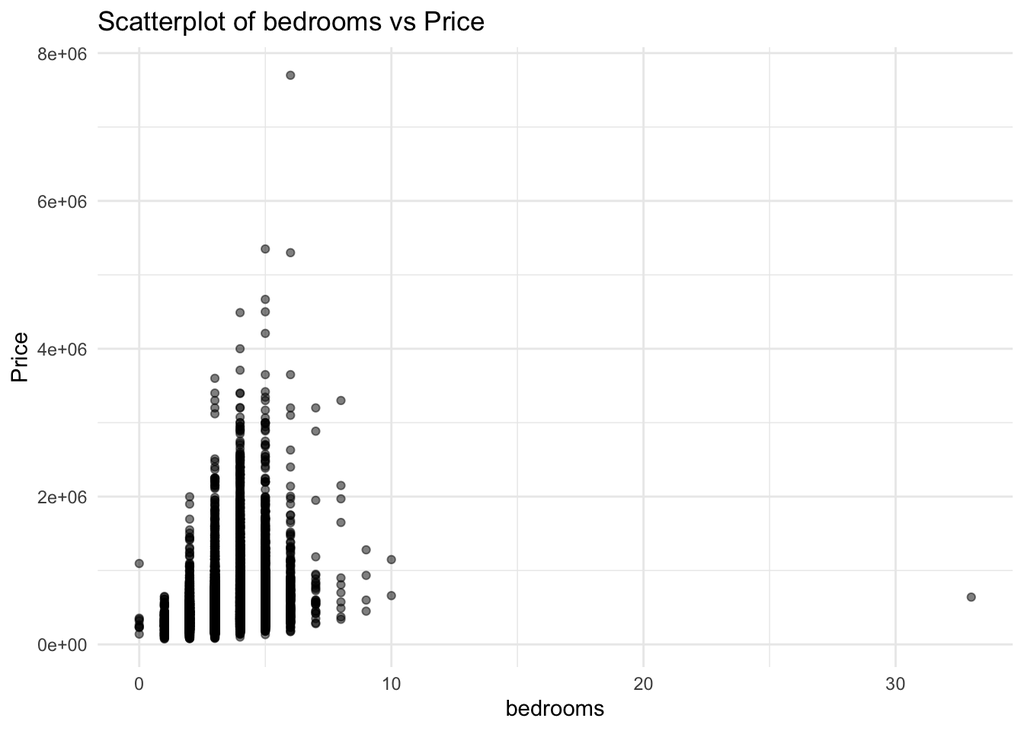

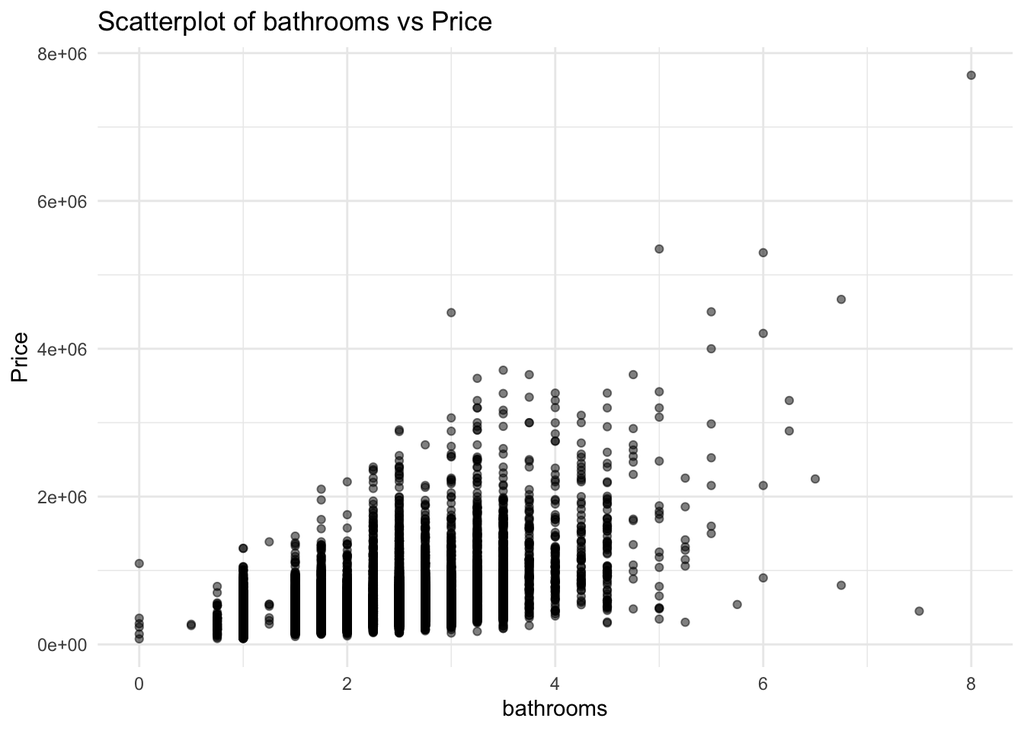

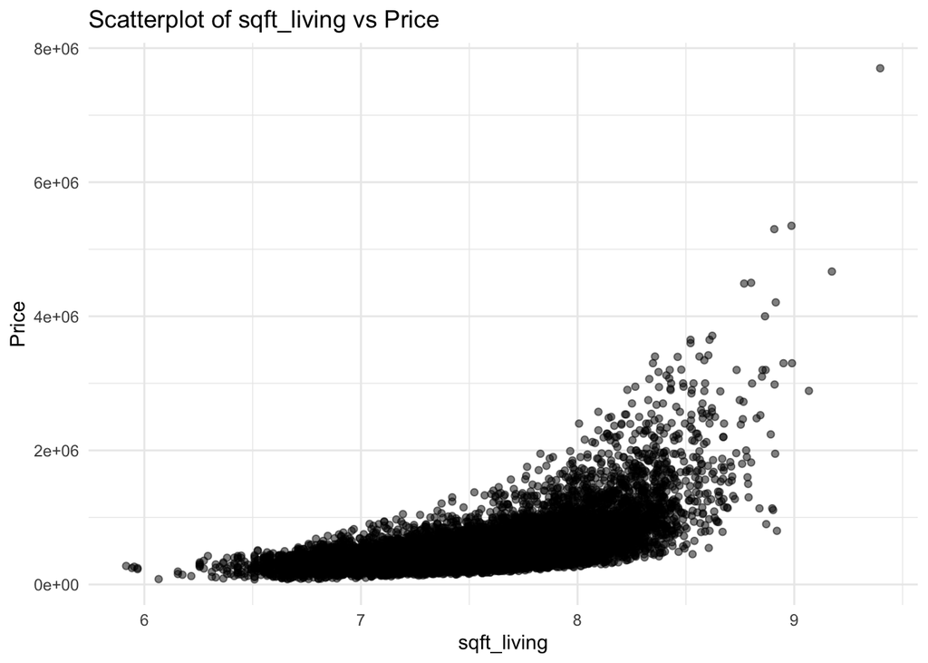

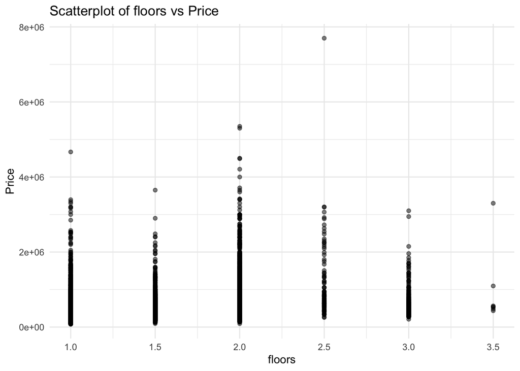

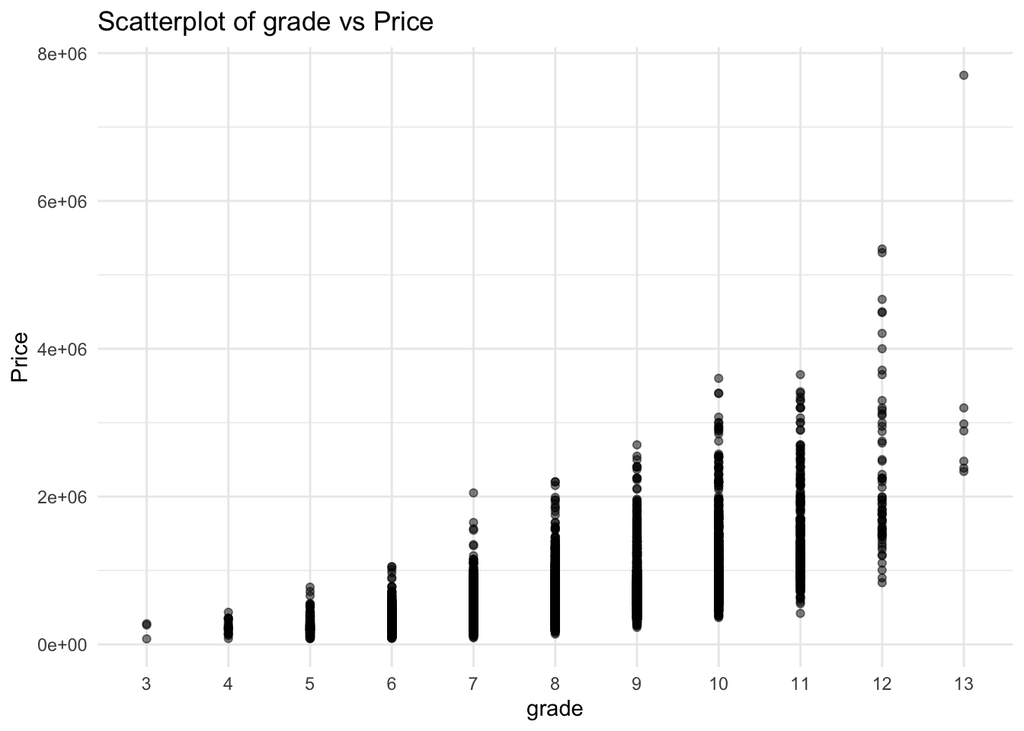

```r
# Select a few key variables for scatterplots
key_variables <- c("bedrooms", "bathrooms", "sqft_living", "floors", "grade")

# Create scatterplots for each key variable against price
for (var in key_variables) {
  plot <- ggplot(train_data_cleaned, aes_string(x = var, y = "price")) +
          geom_point(alpha = 0.5) +
          theme_minimal() +
          labs(title = paste("Scatterplot of", var, "vs Price"),
               x = var, y = "Price")
  print(plot)
}
```

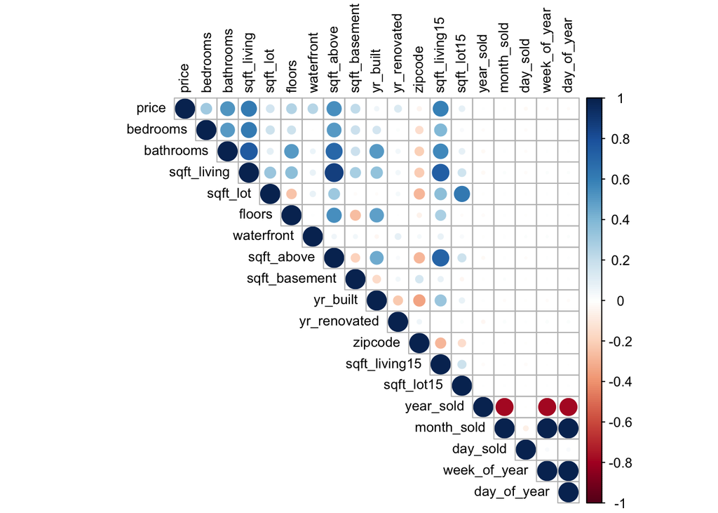

```r
# Compute the correlation matrix
cor_matrix <- cor(train_data_cleaned[, sapply(train_data_cleaned, is.numeric)], use = "complete.obs")

# Plot the correlation matrix
corrplot(cor_matrix, method = "circle", type = "upper", tl.cex = 0.8, tl.col = "black")
```

## Section 3: Model Optimization

### Model Assumptions and Adjustments

Copyright © 2023 Charles and with AI assistance. Fabricated with blood, sweat, and more coffee than a pod of overcaffeinated narwhals. Unauthorized replication of this work will result in a jester performing terribly lame jokes at your next family gathering. Proceed with caution.